# Exam 1

## Exam 1

#### Question

1. Si la mediana de la asistencia a las 6 auditorios de un centro cultural es 415 y no hay dos auditorios con el mismo número de espectadores, ¿cuál es el mayor valor posible para “N”?

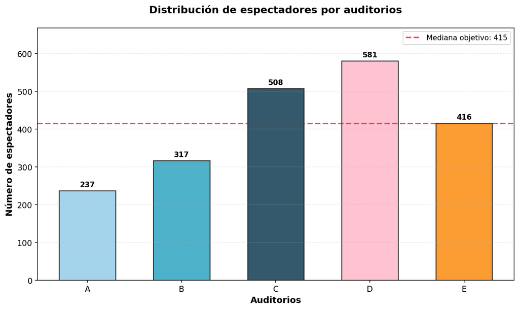

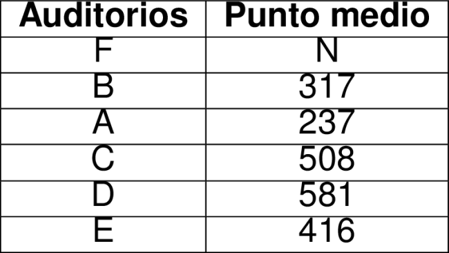

   1. 353
   2. 476
   3. 414
   4. 435

### Análisis del problema

   Para resolver este problema, necesitamos entender qué significa que la mediana sea 415 en un conjunto de 6 valores.

   **Datos conocidos:**
   - Tenemos 6 auditorios: F, B, A, C, D, E
   - Sus valores son: N, 317, 237, 508, 581, 416
   - La mediana del conjunto es 415
   - No hay dos valores iguales

### Concepto de mediana

   La mediana de 6 valores ordenados de menor a mayor es el **promedio de los dos valores centrales (posiciones 3 y 4 )**.

   Para que la mediana sea 415 , cuando ordenemos los 6 valores de menor a mayor, el promedio de los valores en las posiciones 3 y 4 debe ser exactamente 415 .

### Análisis de casos

   Los valores conocidos son: 237, 317, 508, 581, 416

   Analicemos dónde puede ubicarse N para que la mediana sea 415:

   Para que la mediana sea 415 , necesitamos que el promedio de los valores en posiciones 3 y 4 sea 415 .

### Conclusión

   Para que la mediana sea 415 , N debe ser exactamente ** 414 **.
   1. Falso
   2. Falso
   3. Verdadero
   4. Falso